# (Ford GoBike System Data Analysis)

## by (Ahmed Khaled Mohamed)

## Investigation Overview

This data set includes information about individual rides made in a bike-sharing system covering the greater San Francisco Bay area.

This investigation to find the relations between features that affect the bike-sharing system.

## Dataset Overview

This data Collected in 2019 with 183,412 raws data trips for fordgobike in the dataset with 16 Coulmns (duration_sec, start_time, end_time, start_station_id, start_station_name, start_station_latitude, start_station_longitude, end_station_id, end_station_name, end_station_latitude ,end_station_longitude, bike_id, user_type, member_birth_year, member_gender, bike_share_for_all_trip), with a missing values in (start_station_id, start_station_name, end_station_id, end_station_name, member_birth_year, member_gender).

In this data coulmns features divded into a trip duration information(in duration_sec, start_time, end_time), station information(in start_station_id, start_station_name, start_station_latitude, start_station_longitude, end_station_id, end_station_name, end_station_latitude, end_station_longitude),and member information (in bike_id, user_type, member_birth_year, member_gender, bike_share_for_all_trip.

```python
# import all packages and set plots to be embedded inline
import numpy as np
import pandas as pd
import matplotlib.pyplot as plt
import seaborn as sb
import os
import glob

%matplotlib inline

# suppress warnings from final output
import warnings
warnings.simplefilter("ignore")
```

```python
# load the cleaned dataset for drawing
bike = pd.read_csv('bike_clean.csv')
```

> Note that the above cells have been set as "Skip"-type slides. That means that when the notebook is rendered as http slides, those cells won't show up.

### primary conclusion

The duration variated in the dataframe so we need to see the plotting.

- The mean of duration 11
- The median of duration 8
- The mode of duration 4

The main members in the dataframe is males with 74.6% and females with 23.3%.

- The percentage of the males in dataframe is 0.745951
- The percentage of the mfemales in dataframe is 0.233198
- The percentage of the others in dataframe is 0.020851

The main members in the dataframe have a False in bike_share_for_all_trip by 90.1%.

- The percentage of the bike_share_for_all_trip is true in dataframe is 0.099111
- The percentage of the bike_share_for_all_trip is false in dataframe is 0.90088

Most of the members age concentrate in 30s.

- The mean of member_age 35
- The median of member_age 33
- The mode of member_age 32

The distance need to be checked by plotting.

- The mean of distance 1689
- The median of distance 1428
- The mode of distance 0

## 1. Riders gender throw duration of the trip and age analysis

### 1.1. Gender with riders age investigation

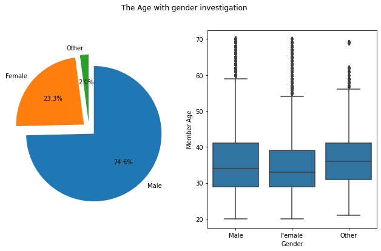

```python
plt.figure(figsize=[11, 6]);
plt.suptitle('The Age with gender investigation');
plt.subplot(1, 2, 1);
sorted_vals = bike.member_gender.value_counts()/bike.shape[0];
explode = (0.1, 0.1, 0.1)
plt.pie(sorted_vals, labels=sorted_vals.index, explode=explode, startangle=90, counterclock=False, autopct='%1.1f%%');

plt.subplot(1, 2, 2);
base_color = sb.color_palette()[0]
sb.boxplot(data=bike, x='member_gender', y='age', color=base_color);
plt.xlabel('Gender');
plt.ylabel('Member Age');
```

### 1.2. Gender with duration in minutes investigation

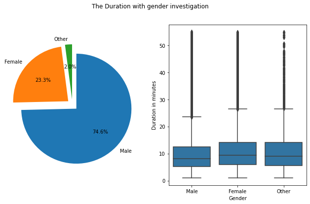

```python
plt.figure(figsize=[11, 6]);
plt.suptitle('The Duration with gender investigation');

plt.subplot(1, 2, 1);
sorted_vals = bike.member_gender.value_counts()/bike.shape[0];
explode = (0.1, 0.1, 0.1)
plt.pie(sorted_vals, labels=sorted_vals.index, explode=explode, startangle=90, counterclock=False, autopct='%1.1f%%');

plt.subplot(1, 2, 2);
base_color = sb.color_palette()[0]
sb.boxplot(data=bike, x='member_gender', y='duration_minute', color=base_color);
plt.xlabel('Gender');
plt.ylabel('Duration in minutes');
```

The trips for gender is nearly the same duration, but male trips take less duration means they are much quicker.

### 1.3. distribution of the riders gender throw duration of the trip and age

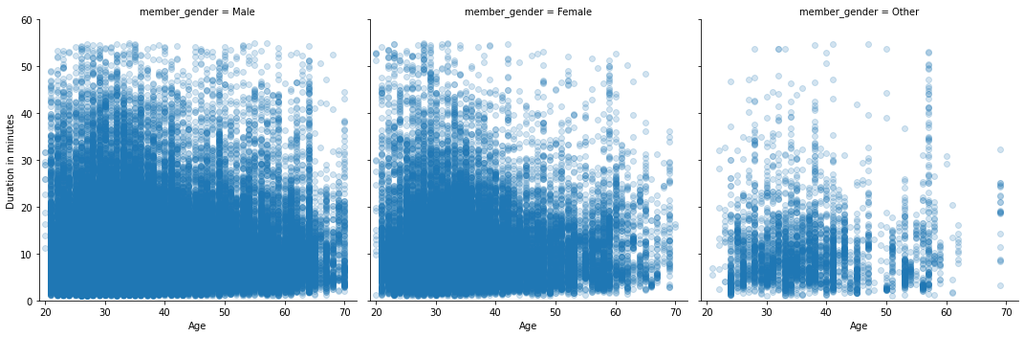

```python
plt.suptitle('The Age with duration distribution in each gender ');

gender = sb.FacetGrid(data = bike, col = 'member_gender', col_wrap = 3, size = 5,
                 xlim = [19, 72], ylim = [0, 60])
gender.map(plt.scatter, 'age', 'duration_minute', alpha= 0.2)
gender.set_xlabels('Age')
gender.set_ylabels('Duration in minutes')
plt.show()
```

## 2. The Hourly Usage during Weekdays for Customers and Subscribers

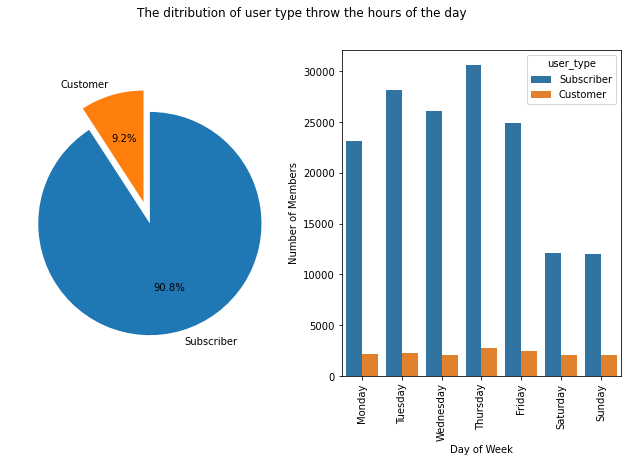

```python
plt.figure(figsize=[11, 6]);
plt.suptitle('The ditribution of user type throw the hours of the day ');

plt.subplot(1, 2, 1);
explode=(0.1,0.1);
sorted_vals = bike.user_type.value_counts()/bike.shape[0];
plt.pie(sorted_vals, labels=sorted_vals.index, explode=explode, startangle=90, counterclock=False, autopct='%1.1f%%');

plt.subplot(1, 2, 2);
day = ['Monday', 'Tuesday', 'Wednesday', 'Thursday', 'Friday', 'Saturday', 'Sunday']
daycat = pd.api.types.CategoricalDtype(ordered=True, categories=day)
bike['start_day'] = bike['start_day'].astype(daycat)
sb.countplot(data=bike, x='start_day', hue='user_type');
plt.xticks(rotation=90)
plt.xlabel('Day of Week');
plt.ylabel('Number of Members');
```

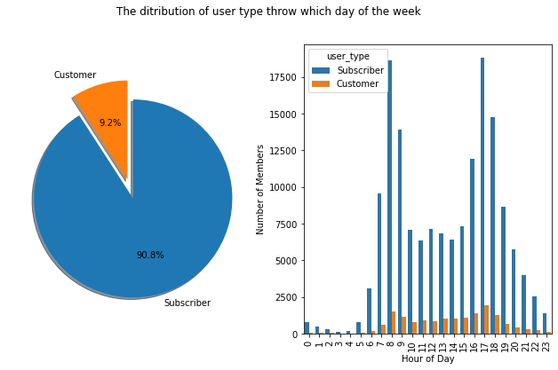

```python
plt.figure(figsize=[11, 6]);
plt.suptitle('The ditribution of user type throw which day of the week ');
plt.subplot(1, 2, 1);
sorted_vals = bike.user_type.value_counts()/bike.shape[0];
explode=(0.1, 0.1);
plt.pie(sorted_vals, explode=explode, labels=sorted_vals.index, startangle=90, counterclock=False, autopct='%1.1f%%', shadow=True);

plt.subplot(1, 2, 2);
sb.countplot(data=bike, x='start_hour', hue='user_type');
plt.xticks(rotation=90)
plt.xlabel('Hour of Day');
plt.ylabel('Number of Members');
```

According to the investigation draws about the subscribers that a use the bike sharing system for work commnute thus most trips were on work days (Mon-Fri) and especially during rush hours unlike the customer that nearly the same riding trips throw the hole week but take long trips in weekend.

### 2.3. Heatmap for the hourly usage during weekdays for Customers and Subscribers

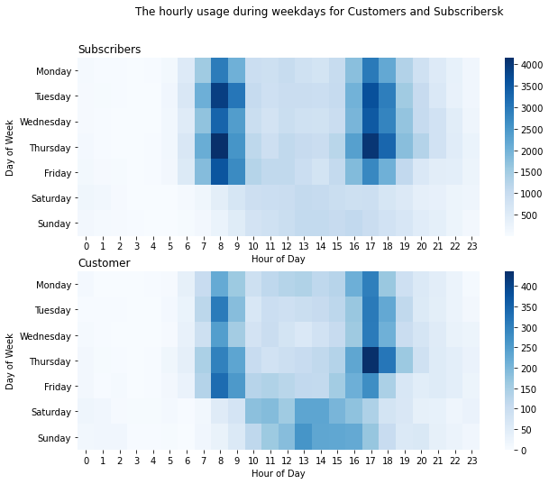

```python
plt.figure(figsize=[10, 8]);
plt.suptitle('The hourly usage during weekdays for Customers and Subscribersk ');
# the Hourly Usage during Weekdays for Subscribers
plt.subplot(2, 1, 1)
subscribers = bike.query('user_type == "Subscriber"')
s = subscribers.groupby(['start_day', 'start_hour']).size()
s = s.reset_index(name='count')
s = s.pivot(index='start_day', columns='start_hour', values='count')
sb.heatmap(s, cmap='Blues');
plt.title('Subscribers', loc='left');
plt.xlabel('Hour of Day');
plt.ylabel('Day of Week');
# the Hourly Usage during Weekdays for Customers
plt.subplot(2, 1, 2)
customers = bike.query('user_type == "Customer"')
c = customers.groupby(['start_day', 'start_hour']).size()
c = c.reset_index(name='count')
c = c.pivot(index='start_day', columns='start_hour', values='count')
sb.heatmap(c, cmap='Blues');
plt.title('Customer', loc='left');
plt.xlabel('Hour of Day');
plt.ylabel('Day of Week');
```

- For subscribers: the number of riders concentated in (Mon-to-Fri)to hit the peak in Tuesday and Thursday, and concentated in early hours a day (06:30 to 09:00) and the afternoon (15:30 to 18:30), leaving a conlusion that a subscribers ride for hiting a target or goal or work comitment.
- For customers: Have the same features of the Subscribers in number of the riders oncentated in (Mon-to-Fri)in the same rush houres like subscribers, but for weekends (sat, sun) theirs also a densty in the graph between 9:30 to 17:00.

## 3. The app. distance VS avg. duration for customers and subscribers throw the week

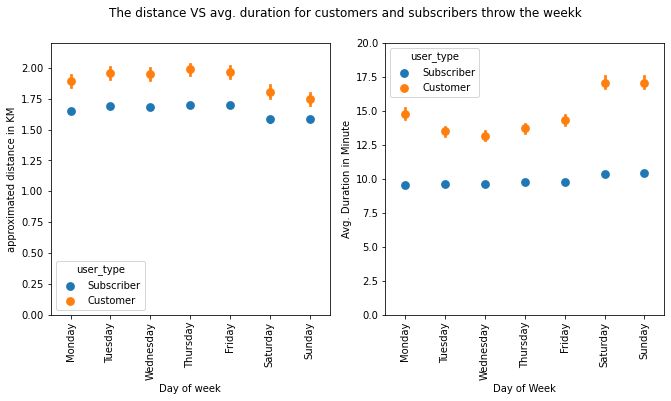

```python
plt.figure(figsize=[11, 5]);
plt.suptitle('The distance VS avg. duration for customers and subscribers throw the weekk ');
# the App. Distance during Weekdays on Subscribers and Customers
plt.subplot(1, 2, 1);
sb.pointplot(data=bike, x='start_day', y='app_distance_km', hue='user_type', linestyles="");
plt.ylim(0, 2.2)
plt.xticks(rotation=90)
plt.xlabel('Day of week');
plt.ylabel('approximated distance in KM');
# the Duration during Weekdays on Subscribers and Customers
plt.subplot(1, 2, 2);
sb.pointplot(data=bike, x='start_day', y='duration_minute', hue='user_type', linestyles="");
plt.ylim(0, 20)
plt.xticks(rotation=90)
plt.xlabel('Day of Week');
plt.ylabel('Avg. Duration in Minute');
```

> Once you're ready to finish your presentation, check your output by using nbconvert to export the notebook and set up a server for the slides. From the terminal or command line, use the following expression:

> > `jupyter nbconvert slide_deck_template.ipynb --to slides --post serve --template output_toggle.tpl`

> This should open a tab in your web browser where you can scroll through your presentation. Sub-slides can be accessed by pressing 'down' when viewing its parent slide. Make sure you remove all of the quote-formatted guide notes like this one before you finish your presentation!

## summary

Accordint to the gender, duration,and age analysis

Acoording to user type and days of week analysis